# Análise de Séries Temporais com R

Lucas Rafael de Andrade

```r
# DOCUMENT LANGUAGE: Brazilian Portuguese
################################################################
################################################################
# imports
#Fç condicional para instalar e carregar pacotes automaticamente
load_libs <- function(libs) {
  new_libs <- libs[!(libs %in% installed.packages()[,"Package"])]
  if(length(new_libs)) install.packages(new_libs)
  invisible(lapply(libs, require, character.only = TRUE))
}

libs <- c("tseries", "forecast", "lmtest", "urca", "FinTS")
load_libs(libs)
```

# TL;DR para GitHubers

Este documento apresenta a resolução da prova de Análise de Séries Temporais, utilizando R para cálculos e geração dinâmica de interpretações estatísticas.

# QUESTÃO 1 - TESTES DE RAIZ UNITÁRIA

## 1. Dados e Visualização

Gerando a série de PIB simulado ($T=100$) conforme enunciado (Passeio Aleatório com Drift).

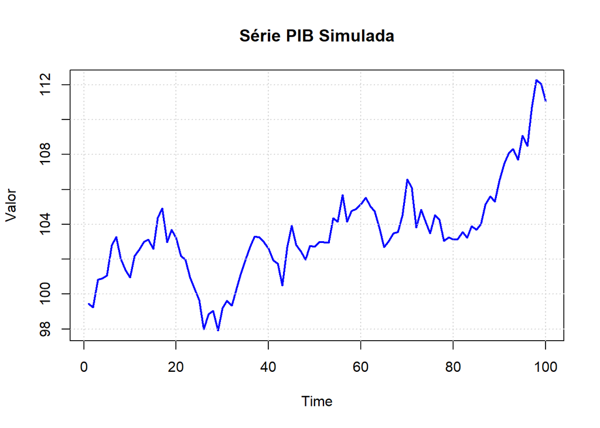

```r
set.seed(123)
# aqui simulo  um random walk (raiz unitária) c/ leve drift
pib <- cumsum(rnorm(100)) + 0.02*(1:100) + 100
pib <- ts(pib)

plot(pib, main = "Série PIB Simulada", ylab = "Valor", col = "blue", lwd = 2)
grid()
```

## 2. Testes Dickey-Fuller (Pacote urca)

Abaixo executamos os testes `ur.df` para as três especificações. A decisão é baseada na estatística $\tau$ (tau) comparada ao valor crítico de 5%.

```r
# (i) Sem constante, sem tendência (tau)
df_none <- ur.df(pib, type = "none", selectlags = "AIC")
stat_none <- df_none@teststat[1]
crit_none <- df_none@cval[1, "5pct"]
#############################################################
# (ii) Com constante, sem tendência (tau_mu)
df_drift <- ur.df(pib, type = "drift", selectlags = "AIC")
stat_drift <- df_drift@teststat[1, 1] # Estatística tau2
crit_drift <- df_drift@cval[1, "5pct"]
##############################################################
# (iii) Com constante, com tendência (tau_tau)
df_trend <- ur.df(pib, type = "trend", selectlags = "AIC")
stat_trend <- df_trend@teststat[1, 1] # Estatística tau3
crit_trend <- df_trend@cval[1, "5pct"]
```

### Resultados e Interpretação Dinâmica:

**H0:** A série possui raiz unitária (Não Estacionária).  
**H1:** A série é estacionária.

**Modelo Sem Constante/Tendência:**

- Estatística de Teste: 1.295
- Valor Crítico (5%): -1.95
- **Decisão:** Como a estatística é maior (menos negativa) que o valor crítico, não rejeitamos a hipótese nula.

**Modelo Com Drift:**

- Estatística de Teste: -0.849
- Valor Crítico (5%): -2.89
- **Decisão:** Não rejeitamos a hipótese nula.

**Modelo Com Tendência:**

- Estatística de Teste: -1.923
- Valor Crítico (5%): -3.45
- **Decisão:** Não rejeitamos a hipótese nula.

## 3. Teste ADF Padrão (tseries)

```r
adf_res <- adf.test(pib)
print(adf_res)
```

```
##
##  Augmented Dickey-Fuller Test
##
## data:  pib
## Dickey-Fuller = -1.8871, Lag order = 4, p-value = 0.6234
## alternative hypothesis: stationary
```

### Interpretação:

O p-value é 0.6234. Como este valor é maior que 0.05, não rejeitamos H0.

Isso indica que a série possui raiz unitária (Não Estacionária).

## 4. Teste KPSS

O teste KPSS inverte as hipóteses:

**H0:** A série é estacionária.  
**H1:** A série possui raiz unitária.

```r
kpss_res <- kpss.test(pib, null = "Level")
print(kpss_res)
```

```
##
##  KPSS Test for Level Stationarity
##
## data:  pib
## KPSS Level = 1.2932, Truncation lag parameter = 4, p-value = 0.01
```

### Interpretação:

O p-value é 0.01. Como este valor é menor que 0.05, **rejeitamos H0**.

Isso fornece evidência a favor da não estacionariedade.

## 5. Conclusão Final (Questão 1)

Considerando que o teste ADF não rejeitou a presença de raiz unitária e o teste KPSS rejeitou a estacionariedade, concluímos que a série PIB é **Não Estacionária**. Seria necessário aplicar diferenciação ($\Delta y_t$) para torná-la adequada para modelagem ARMA.

# QUESTÃO 2 - IDENTIFICAÇÃO E DIAGNÓSTICO ARIMA

## 1. Dados e Identificação Visual

Simulação do processo ARMA(2,1):

```r
set.seed(456)
n <- 250
eps <- rnorm(n)
y <- numeric(n)
y[1:2] <- rnorm(2)
for(t in 3:n) {
    # ARMA(2,1) segue essa formula:  y[t] = 0.8*y[t-1] - 0.2*y[t-2] + 0.5*eps[t-1] + eps[t]
    y[t] <- 0.8*y[t-1] - 0.2*y[t-2] + 0.5*eps[t-1] + eps[t]
}
y <- ts(y)
```

### (a) Gráficos FAC e FACP

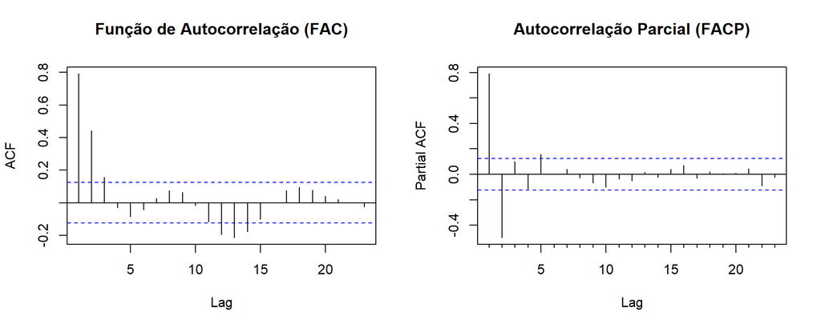

```r
par(mfrow=c(1,2))
Acf(y, main="Função de Autocorrelação (FAC)")
Pacf(y, main="Autocorrelação Parcial (FACP)")
```

```r
par(mfrow=c(1,1))
```

**Interpretação Visual:**

Observamos um decaimento na FAC e na FACP. Não há um corte abrupto claro no lag 1 da FAC (típico de MA puro) nem apenas no lag 2 da FACP (típico de AR puro), embora os primeiros lags sejam significativos em ambos. Esse comportamento de persistência/decaimento em ambas as funções sugere um modelo misto ARMA(p,q). Dado o enunciado, esperamos identificar p=2 e q=1.

## 2. Estimação e Seleção Automática

### (b) Estimação Manual ARIMA(2,0,1)

```r
modelo_manual <- Arima(y, order=c(2,0,1))
summary(modelo_manual)
```

```
## Series: y
## ARIMA(2,0,1) with non-zero mean
##
## Coefficients:
##          ar1      ar2     ma1    mean
##       0.8611  -0.2353  0.4174  0.1328
## s.e.  0.1438   0.1275  0.1500  0.2325
##
## sigma^2 = 0.9668:  log likelihood = -349.32
## AIC=708.65   AICc=708.9   BIC=726.26
##
## Training set error measures:
##                        ME      RMSE       MAE     MPE     MAPE      MASE
## Training set 0.0002243846 0.9753804 0.8054832 35.6212 214.1279 0.8257946
##                     ACF1
## Training set -0.00916011
```

Os coeficientes estimados foram:

- **AR(1):** 0.861 (Real: 0.8)
- **AR(2):** -0.235 (Real: -0.2)
- **MA(1):** 0.417 (Real: 0.5)

### (c) Seleção Automática (Auto.Arima)

```r
modelo_auto <- auto.arima(y, seasonal = FALSE, stepwise = FALSE, approximation = FALSE)
summary(modelo_auto)
```

```
## Series: y
## ARIMA(5,0,0) with zero mean
##
## Coefficients:
##          ar1      ar2     ar3      ar4     ar5
##       1.2626  -0.7218  0.3493  -0.3108  0.1596
## s.e.  0.0623   0.1001  0.1087   0.1008  0.0629
##
## sigma^2 = 0.947:  log likelihood = -346.28
## AIC=704.56   AICc=704.91   BIC=725.69
##
## Training set error measures:
##                      ME      RMSE       MAE      MPE    MAPE      MASE
## Training set 0.03405736 0.9633577 0.8006278 41.77261 215.008 0.8208168
##                    ACF1
## Training set 0.00301705
```

```r
# Comparaç dinâmica
aic_manual <- modelo_manual$aic
aic_auto <- modelo_auto$aic
melhor_aic <- min(aic_manual, aic_auto)
```

**Comparação:**

- AIC do Modelo Manual (2,0,1): 708.65
- AIC do Auto Arima (5,0,0): 704.56

O modelo selecionado pelo auto.arima diferiu da especificação teórica. O modelo com menor AIC (melhor ajuste penalizado) é o Auto Arima.

## 3. Diagnóstico de Resíduos

### (d) Teste de Ljung-Box (Independência)

Verificamos se restou autocorrelação nos resíduos (se são ruído branco).

```r
# teste c lag=10 como pedido
lb_teste <- Box.test(residuals(modelo_manual), lag=10, type="Ljung-Box")
print(lb_teste)
```

```
##
##  Box-Ljung test
##
## data:  residuals(modelo_manual)
## X-squared = 8.1739, df = 10, p-value = 0.6119
```

**Análise do P-value:**

O p-value é 0.6119.

**Conclusão:** Não regeitamos H0. Os resíduos são independentes (adequado).

### (e) Teste ARCH-LM (Homocedasticidade)

Verificamos se há heterocedasticidade condicional (efeito ARCH).

```r
# Requer pacote FinTS
arch_res <- FinTS::ArchTest(residuals(modelo_manual), lags=5)
print(arch_res)
```

```
##
##  ARCH LM-test; Null hypothesis: no ARCH effects
##
## data:  residuals(modelo_manual)
## Chi-squared = 3.1012, df = 5, p-value = 0.6844
```

**Análise do P-value:**

O p-value é 0.6844.

**Conclusão:** Não rejeitamos H0. Os resíduos são homocedásticos (variância constante).

# Referências e Agradecimentos

Gostaria de agradecer primeiro ao Fernando da Silva (YT: Anal. Macro) pelas incríveis aulas, bem como a Professora Vanessa Manhães(YT: homônimo).

Também agradecer aos desenvolvedores da IA llama-2-7b-chat.Q4_K_M

https://stats.stackexchange.com/questions/24072/interpreting-rs-ur-df-dickey-fuller-unit-root-test-results

links:

https://cran.r-project.org/web/packages/urca/urca.pdf

https://atsa-es.github.io/atsa-labs/sec-boxjenkins-aug-dickey-fuller.html

https://www.r-bloggers.com/2021/12/augmented-dickey-fuller-adf-test-in-r/

https://otexts.com/fpp2/arima-r.html

https://www.rdocumentation.org/packages/forecast/versions/8.24.0/topics/auto.arima

https://blogs.oracle.com/ai-and-datascience/introduction-to-forecasting-with-arima-in-r

https://www.listendata.com/2015/10/arima-modeling-with-r.html

https://search.r-project.org/CRAN/refmans/nortsTest/html/arch.test.html

https://restateinsight.com/posts/general-posts/repost-arima-no-r/

https://www.youtube.com/watch?v=nm45WagtV3w

“Nesse mundo nada de cria, tudo se copia” - D. Robaina, o melhor professor de programação!

Esse código é de Lucas?